```python
from IPython.display import HTML

HTML('''<script> code_show=true; function code_toggle() { $('div.input').hide(); } $( document ).ready(code_toggle); </script> ''')
```

# Data Analysis: WeRateDogs Twitter Account

> Written by Kieran Shand
- Introduction
- Analysis
  - Rating trends
  - Rating Attributes
  - Rating and audience interaction
- Conclusion
- Sources

## Introduction

In this report, I will be completing a data analysis on the tweet archive of WeRateDogs (@dog_rates): *'WeRateDogs is a Twitter account that rates people's dogs with a humorous comment about the dog'.*

WeRateDogs has an international audience with over 8.7 million followers. Having completed an earlier Data Wrangling exercise, I will analyse the master file consisting of 2000+ tweets utilising insightful visualisations to answer the questions I have posed the report.

```
1. How have ratings trended over time?
2. What makes a highly rated Dog?
3. Is there a relationship between ratings and audience interaction?
```

Finally, a well documented conclusion will form a summary of the main findings of the report.

## Analysis

### Rating Trend

Overtime, there is therefore a tendancy of WeRateDogs to tweet less frequently, but to offer higher quality ratings. Perhaps it's quality over quantity...

*Figure 1 - Time Series: Rating Average & Count*

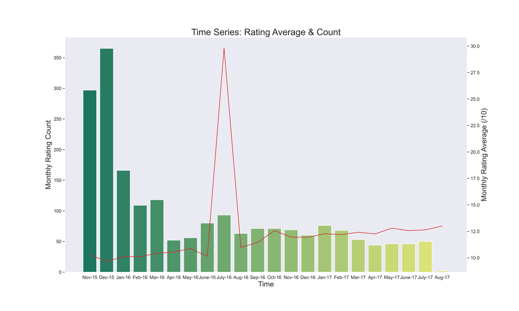

```python
from IPython.display import Image
Image(filename='monthly_ratings_and_count.png')
```